# Analysis of football player performnace

Karan Bhatt

Installing the necessary packages that we are using.

```r
install.packages("dpylr")
install.packages("ggplot2")
```

```
Error in install.packages : Updating loaded packages
```

```r
install.packages("gridExtra")
install.packages("ggplot2")
install.packages("moments")
install.packages("corrplot")
install.packages("ggcorrplot")
install.packages("caTools")
install.packages("caret")
```

```
Error in install.packages : Updating loaded packages
```

```r
install.packages("car")
install.packages("Metrics")
install.packages("DataExplorer")
install.packages("maps")
install.packages("plotly")
install.packages("randomForest")
```

Importing useful libraries

```r
library(dplyr)
library(readr)
library(ggplot2)
library(gridExtra)
library(moments)
library(corrplot)
library(ggcorrplot)
library(MASS)
library(caTools)
library(caret)
library(car)
library(Metrics)
library(tidyverse)
library(DataExplorer)
library(magrittr)
library(maps)
library(plotly)
library(randomForest)
```

Importing the dataset

```r
df <- read_csv("D:/LSBU/Statistical Analysis Modeling/Dataset/archive/fifa_eda_stats.csv", locale = locale(encoding = "UTF-8"))
View(df)
head(df)
```

| ID | Name | Age | Nationality | Overall | Potential | Club | Value | Wage | Preferred Foot | International Reputation | Weak Foot | Skill Moves | Work Rate | Body Type | Position | Jersey Number | Joined | Loaned From | Contract Valid Until | Height | Weight | Crossing | Finishing | HeadingAccuracy | ShortPassing | Volleys | Dribbling | Curve | FKAccuracy | … |
| --- | --- | --- | --- | --- | --- | --- | --- | --- | --- | --- | --- | --- | --- | --- | --- | --- | --- | --- | --- | --- | --- | --- | --- | --- | --- | --- | --- | --- | --- | --- |
| 158023 | L. Messi | 31 | Argentina | 94 | 94 | FC Barcelona | €110.5M | €565K | Left | 5 | 4 | 4 | Medium/ Medium | Messi | RF | 10 | Jul 1, 2004 | NA | 2021 | 5'7 | 159lbs | 84 | 95 | 70 | 90 | 86 | 97 | 93 | 94 | … |
| 20801 | Cristiano Ronaldo | 33 | Portugal | 94 | 94 | Juventus | €77M | €405K | Right | 5 | 4 | 5 | High/ Low | C. Ronaldo | ST | 7 | Jul 10, 2018 | NA | 2022 | 6'2 | 183lbs | 84 | 94 | 89 | 81 | 87 | 88 | 81 | 76 | … |
| 190871 | Neymar Jr | 26 | Brazil | 92 | 93 | Paris Saint-Germain | €118.5M | €290K | Right | 5 | 5 | 5 | High/ Medium | Neymar | LW | 10 | Aug 3, 2017 | NA | 2022 | 5'9 | 150lbs | 79 | 87 | 62 | 84 | 84 | 96 | 88 | 87 | … |
| 193080 | De Gea | 27 | Spain | 91 | 93 | Manchester United | €72M | €260K | Right | 4 | 3 | 1 | Medium/ Medium | Lean | GK | 1 | Jul 1, 2011 | NA | 2020 | 6'4 | 168lbs | 17 | 13 | 21 | 50 | 13 | 18 | 21 | 19 | … |
| 192985 | K. De Bruyne | 27 | Belgium | 91 | 92 | Manchester City | €102M | €355K | Right | 4 | 5 | 4 | High/ High | Normal | RCM | 7 | Aug 30, 2015 | NA | 2023 | 5'11 | 154lbs | 93 | 82 | 55 | 92 | 82 | 86 | 85 | 83 | … |
| 183277 | E. Hazard | 27 | Belgium | 91 | 91 | Chelsea | €93M | €340K | Right | 4 | 4 | 4 | High/ Medium | Normal | LF | 10 | Jul 1, 2012 | NA | 2020 | 5'8 | 163lbs | 81 | 84 | 61 | 89 | 80 | 95 | 83 | 79 | … |

checking the dimention of data frame

```r
dim(df)
```

```
[1] 18207    57
```

Removing the unnecessary columns for analysis

```r
df1 <- df [,-c(14,15,16,17,18,19,20,57)]
View(df1)
head(df1)
```

| ID | Name | Age | Nationality | Overall | Potential | Club | Value | Wage | Preferred Foot | International Reputation | Weak Foot | Skill Moves | Height | Weight | Crossing | Finishing | HeadingAccuracy | ShortPassing | Volleys | Dribbling | Curve | FKAccuracy | LongPassing | BallControl | Acceleration | SprintSpeed | Agility | Reactions | Balance | … |
| --- | --- | --- | --- | --- | --- | --- | --- | --- | --- | --- | --- | --- | --- | --- | --- | --- | --- | --- | --- | --- | --- | --- | --- | --- | --- | --- | --- | --- | --- | --- |
| 158023 | L. Messi | 31 | Argentina | 94 | 94 | FC Barcelona | €110.5M | €565K | Left | 5 | 4 | 4 | 5'7 | 159lbs | 84 | 95 | 70 | 90 | 86 | 97 | 93 | 94 | 87 | 96 | 91 | 86 | 91 | 95 | 95 | … |
| 20801 | Cristiano Ronaldo | 33 | Portugal | 94 | 94 | Juventus | €77M | €405K | Right | 5 | 4 | 5 | 6'2 | 183lbs | 84 | 94 | 89 | 81 | 87 | 88 | 81 | 76 | 77 | 94 | 89 | 91 | 87 | 96 | 70 | … |
| 190871 | Neymar Jr | 26 | Brazil | 92 | 93 | Paris Saint-Germain | €118.5M | €290K | Right | 5 | 5 | 5 | 5'9 | 150lbs | 79 | 87 | 62 | 84 | 84 | 96 | 88 | 87 | 78 | 95 | 94 | 90 | 96 | 94 | 84 | … |
| 193080 | De Gea | 27 | Spain | 91 | 93 | Manchester United | €72M | €260K | Right | 4 | 3 | 1 | 6'4 | 168lbs | 17 | 13 | 21 | 50 | 13 | 18 | 21 | 19 | 51 | 42 | 57 | 58 | 60 | 90 | 43 | … |
| 192985 | K. De Bruyne | 27 | Belgium | 91 | 92 | Manchester City | €102M | €355K | Right | 4 | 5 | 4 | 5'11 | 154lbs | 93 | 82 | 55 | 92 | 82 | 86 | 85 | 83 | 91 | 91 | 78 | 76 | 79 | 91 | 77 | … |
| 183277 | E. Hazard | 27 | Belgium | 91 | 91 | Chelsea | €93M | €340K | Right | 4 | 4 | 4 | 5'8 | 163lbs | 81 | 84 | 61 | 89 | 80 | 95 | 83 | 79 | 83 | 94 | 94 | 88 | 95 | 90 | 94 | … |

checking the dimesion of new dataframe

```r
dim(df1)
```

```
[1] 18207    49
```

```r
#make.names(names(df1))
#head(df1)
```

Checking total number of missing observation

```r
introduce(df1)
```

| rows | columns | discrete_columns | continuous_columns | all_missing_columns | total_missing_values | complete_rows | total_observations | memory_usage |
| --- | --- | --- | --- | --- | --- | --- | --- | --- |
| 18207 | 49 | 8 | 41 | 0 | 2161 | 17918 | 892143 | 8321512 |

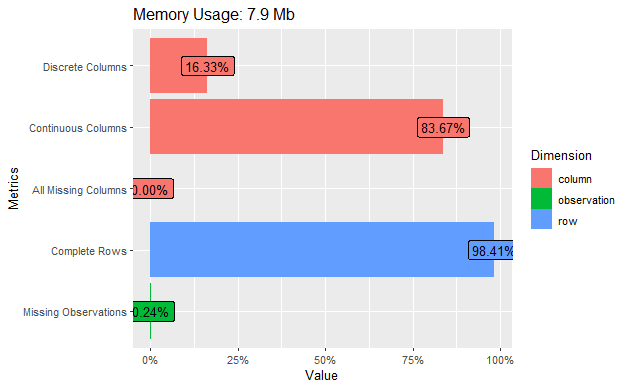

```r
plot_intro(df1)
```

checking total number of missing observation column and also checking null values

```r
sum(is.na(df1))
```

```
[1] 2161
```

```r
sum(is.null(df1))
```

```
[1] 0
```

Removing the missing observation and storing in new data frame

```r
df2 <- na.omit(df1)
head(df2)
```

| ID | Name | Age | Nationality | Overall | Potential | Club | Value | Wage | Preferred Foot | International Reputation | Weak Foot | Skill Moves | Height | Weight | Crossing | Finishing | HeadingAccuracy | ShortPassing | Volleys | Dribbling | Curve | FKAccuracy | LongPassing | BallControl | Acceleration | SprintSpeed | Agility | Reactions | Balance | … |
| --- | --- | --- | --- | --- | --- | --- | --- | --- | --- | --- | --- | --- | --- | --- | --- | --- | --- | --- | --- | --- | --- | --- | --- | --- | --- | --- | --- | --- | --- | --- |
| 158023 | L. Messi | 31 | Argentina | 94 | 94 | FC Barcelona | €110.5M | €565K | Left | 5 | 4 | 4 | 5'7 | 159lbs | 84 | 95 | 70 | 90 | 86 | 97 | 93 | 94 | 87 | 96 | 91 | 86 | 91 | 95 | 95 | … |
| 20801 | Cristiano Ronaldo | 33 | Portugal | 94 | 94 | Juventus | €77M | €405K | Right | 5 | 4 | 5 | 6'2 | 183lbs | 84 | 94 | 89 | 81 | 87 | 88 | 81 | 76 | 77 | 94 | 89 | 91 | 87 | 96 | 70 | … |
| 190871 | Neymar Jr | 26 | Brazil | 92 | 93 | Paris Saint-Germain | €118.5M | €290K | Right | 5 | 5 | 5 | 5'9 | 150lbs | 79 | 87 | 62 | 84 | 84 | 96 | 88 | 87 | 78 | 95 | 94 | 90 | 96 | 94 | 84 | … |
| 193080 | De Gea | 27 | Spain | 91 | 93 | Manchester United | €72M | €260K | Right | 4 | 3 | 1 | 6'4 | 168lbs | 17 | 13 | 21 | 50 | 13 | 18 | 21 | 19 | 51 | 42 | 57 | 58 | 60 | 90 | 43 | … |
| 192985 | K. De Bruyne | 27 | Belgium | 91 | 92 | Manchester City | €102M | €355K | Right | 4 | 5 | 4 | 5'11 | 154lbs | 93 | 82 | 55 | 92 | 82 | 86 | 85 | 83 | 91 | 91 | 78 | 76 | 79 | 91 | 77 | … |
| 183277 | E. Hazard | 27 | Belgium | 91 | 91 | Chelsea | €93M | €340K | Right | 4 | 4 | 4 | 5'8 | 163lbs | 81 | 84 | 61 | 89 | 80 | 95 | 83 | 79 | 83 | 94 | 94 | 88 | 95 | 90 | 94 | … |

```r
sum(is.na(df1))
```

```
[1] 2161
```

```r
sum(is.na(df2))
```

```
[1] 0
```

Stirng manipulation for value and wage column

```r
df2$Wage = gsub("€","",df2$Wage)
df2$Wage = as.numeric(gsub("K","",df2$Wage))
df2$Value = gsub("€","",df2$Value)
df2$Value = as.numeric(gsub("M","",df2$Value))
head(df2)
```

| ID | Name | Age | Nationality | Overall | Potential | Club | Value | Wage | Preferred Foot | International Reputation | Weak Foot | Skill Moves | Height | Weight | Crossing | Finishing | HeadingAccuracy | ShortPassing | Volleys | Dribbling | Curve | FKAccuracy | LongPassing | BallControl | Acceleration | SprintSpeed | Agility | Reactions | Balance | … |
| --- | --- | --- | --- | --- | --- | --- | --- | --- | --- | --- | --- | --- | --- | --- | --- | --- | --- | --- | --- | --- | --- | --- | --- | --- | --- | --- | --- | --- | --- | --- |
| 158023 | L. Messi | 31 | Argentina | 94 | 94 | FC Barcelona | 110.5 | 565 | Left | 5 | 4 | 4 | 5'7 | 159lbs | 84 | 95 | 70 | 90 | 86 | 97 | 93 | 94 | 87 | 96 | 91 | 86 | 91 | 95 | 95 | … |
| 20801 | Cristiano Ronaldo | 33 | Portugal | 94 | 94 | Juventus | 77.0 | 405 | Right | 5 | 4 | 5 | 6'2 | 183lbs | 84 | 94 | 89 | 81 | 87 | 88 | 81 | 76 | 77 | 94 | 89 | 91 | 87 | 96 | 70 | … |
| 190871 | Neymar Jr | 26 | Brazil | 92 | 93 | Paris Saint-Germain | 118.5 | 290 | Right | 5 | 5 | 5 | 5'9 | 150lbs | 79 | 87 | 62 | 84 | 84 | 96 | 88 | 87 | 78 | 95 | 94 | 90 | 96 | 94 | 84 | … |
| 193080 | De Gea | 27 | Spain | 91 | 93 | Manchester United | 72.0 | 260 | Right | 4 | 3 | 1 | 6'4 | 168lbs | 17 | 13 | 21 | 50 | 13 | 18 | 21 | 19 | 51 | 42 | 57 | 58 | 60 | 90 | 43 | … |
| 192985 | K. De Bruyne | 27 | Belgium | 91 | 92 | Manchester City | 102.0 | 355 | Right | 4 | 5 | 4 | 5'11 | 154lbs | 93 | 82 | 55 | 92 | 82 | 86 | 85 | 83 | 91 | 91 | 78 | 76 | 79 | 91 | 77 | … |
| 183277 | E. Hazard | 27 | Belgium | 91 | 91 | Chelsea | 93.0 | 340 | Right | 4 | 4 | 4 | 5'8 | 163lbs | 81 | 84 | 61 | 89 | 80 | 95 | 83 | 79 | 83 | 94 | 94 | 88 | 95 | 90 | 94 | … |

```r
df3<-df2
head(df3)
```

| ID | Name | Age | Nationality | Overall | Potential | Club | Value | Wage | Preferred Foot | International Reputation | Weak Foot | Skill Moves | Height | Weight | Crossing | Finishing | HeadingAccuracy | ShortPassing | Volleys | Dribbling | Curve | FKAccuracy | LongPassing | BallControl | Acceleration | SprintSpeed | Agility | Reactions | Balance | … |
| --- | --- | --- | --- | --- | --- | --- | --- | --- | --- | --- | --- | --- | --- | --- | --- | --- | --- | --- | --- | --- | --- | --- | --- | --- | --- | --- | --- | --- | --- | --- |
| 158023 | L. Messi | 31 | Argentina | 94 | 94 | FC Barcelona | 110.5 | 565 | Left | 5 | 4 | 4 | 5'7 | 159lbs | 84 | 95 | 70 | 90 | 86 | 97 | 93 | 94 | 87 | 96 | 91 | 86 | 91 | 95 | 95 | … |
| 20801 | Cristiano Ronaldo | 33 | Portugal | 94 | 94 | Juventus | 77.0 | 405 | Right | 5 | 4 | 5 | 6'2 | 183lbs | 84 | 94 | 89 | 81 | 87 | 88 | 81 | 76 | 77 | 94 | 89 | 91 | 87 | 96 | 70 | … |
| 190871 | Neymar Jr | 26 | Brazil | 92 | 93 | Paris Saint-Germain | 118.5 | 290 | Right | 5 | 5 | 5 | 5'9 | 150lbs | 79 | 87 | 62 | 84 | 84 | 96 | 88 | 87 | 78 | 95 | 94 | 90 | 96 | 94 | 84 | … |
| 193080 | De Gea | 27 | Spain | 91 | 93 | Manchester United | 72.0 | 260 | Right | 4 | 3 | 1 | 6'4 | 168lbs | 17 | 13 | 21 | 50 | 13 | 18 | 21 | 19 | 51 | 42 | 57 | 58 | 60 | 90 | 43 | … |
| 192985 | K. De Bruyne | 27 | Belgium | 91 | 92 | Manchester City | 102.0 | 355 | Right | 4 | 5 | 4 | 5'11 | 154lbs | 93 | 82 | 55 | 92 | 82 | 86 | 85 | 83 | 91 | 91 | 78 | 76 | 79 | 91 | 77 | … |
| 183277 | E. Hazard | 27 | Belgium | 91 | 91 | Chelsea | 93.0 | 340 | Right | 4 | 4 | 4 | 5'8 | 163lbs | 81 | 84 | 61 | 89 | 80 | 95 | 83 | 79 | 83 | 94 | 94 | 88 | 95 | 90 | 94 | … |

Showing the summary of dataframe

```r
str(df3)
```

```
tibble [17,918 × 49] (S3: tbl_df/tbl/data.frame)
 $ ID                      : num [1:17918] 158023 20801 190871 193080 192985 ...
 $ Name                    : chr [1:17918] "L. Messi" "Cristiano Ronaldo" "Neymar Jr" "De Gea" ...
 $ Age                     : num [1:17918] 31 33 26 27 27 27 32 31 32 25 ...
 $ Nationality             : chr [1:17918] "Argentina" "Portugal" "Brazil" "Spain" ...
 $ Overall                 : num [1:17918] 94 94 92 91 91 91 91 91 91 90 ...
 $ Potential               : num [1:17918] 94 94 93 93 92 91 91 91 91 93 ...
 $ Club                    : chr [1:17918] "FC Barcelona" "Juventus" "Paris Saint-Germain" "Manchester United" ...
 $ Value                   : num [1:17918] 110 77 118 72 102 ...
 $ Wage                    : num [1:17918] 565 405 290 260 355 340 420 455 380 94 ...
 $ Preferred Foot          : chr [1:17918] "Left" "Right" "Right" "Right" ...
 $ International Reputation: num [1:17918] 5 5 5 4 4 4 4 5 4 3 ...
 $ Weak Foot               : num [1:17918] 4 4 5 3 5 4 4 4 3 3 ...
 $ Skill Moves             : num [1:17918] 4 5 5 1 4 4 4 3 3 1 ...
 $ Height                  : chr [1:17918] "5'7" "6'2" "5'9" "6'4" ...
```

[output cut: 37 more lines]

Showing the summary of data set

```r
summary(df3)
```

```
       ID             Name                Age        Nationality           Overall        Potential         Club
 Min.   :    16   Length:17918       Min.   :16.00   Length:17918       Min.   :46.00   Min.   :48.00   Length:17918
 1st Qu.:200235   Class :character   1st Qu.:21.00   Class :character   1st Qu.:62.00   1st Qu.:67.00   Class :character
 Median :221702   Mode  :character   Median :25.00   Mode  :character   Median :66.00   Median :71.00   Mode  :character
 Mean   :214226                      Mean   :25.11                      Mean   :66.24   Mean   :71.33
 3rd Qu.:236509                      3rd Qu.:28.00                      3rd Qu.:71.00   3rd Qu.:75.00
 Max.   :246620                      Max.   :45.00                      Max.   :94.00   Max.   :95.00

     Value              Wage         Preferred Foot     International Reputation   Weak Foot      Skill Moves
 Min.   :  0.000   Min.   :  1.000   Length:17918       Min.   :1.000            Min.   :1.000   Min.   :1.000
 1st Qu.:  1.600   1st Qu.:  1.000   Class :character   1st Qu.:1.000            1st Qu.:3.000   1st Qu.:2.000
 Median :  3.100   Median :  3.000   Mode  :character   Median :1.000            Median :3.000   Median :2.000
 Mean   :  5.702   Mean   :  9.884                      Mean   :1.114            Mean   :2.947   Mean   :2.363
 3rd Qu.:  6.500   3rd Qu.:  9.000                      3rd Qu.:1.000            3rd Qu.:3.000   3rd Qu.:3.000
 Max.   :118.500   Max.   :565.000                      Max.   :5.000            Max.   :5.000   Max.   :5.000
 NA's   :11060
    Height             Weight             Crossing       Finishing     HeadingAccuracy  ShortPassing      Volleys
 Length:17918       Length:17918       Min.   : 5.00   Min.   : 2.00   Min.   : 4.0    Min.   : 7.00   Min.   : 4.00
 Class :character   Class :character   1st Qu.:38.00   1st Qu.:30.00   1st Qu.:44.0    1st Qu.:54.00   1st Qu.:30.00
 Mode  :character   Mode  :character   Median :54.00   Median :49.00   Median :56.0    Median :62.00   Median :44.00
                                       Mean   :49.75   Mean   :45.58   Mean   :52.3    Mean   :58.71   Mean   :42.93
                                       3rd Qu.:64.00   3rd Qu.:62.00   3rd Qu.:64.0    3rd Qu.:68.00   3rd Qu.:57.00
                                       Max.   :93.00   Max.   :95.00   Max.   :94.0    Max.   :93.00   Max.   :90.00

   Dribbling         Curve         FKAccuracy     LongPassing     BallControl     Acceleration   SprintSpeed
 Min.   : 4.00   Min.   : 6.00   Min.   : 3.00   Min.   : 9.00   Min.   : 5.00   Min.   :12.0   Min.   :12.00
 1st Qu.:49.00   1st Qu.:34.00   1st Qu.:31.00   1st Qu.:43.00   1st Qu.:54.00   1st Qu.:57.0   1st Qu.:57.00
 Median :61.00   Median :49.00   Median :41.00   Median :56.00   Median :63.00   Median :67.0   Median :67.00
 Mean   :55.41   Mean   :47.22   Mean   :42.88   Mean   :52.72   Mean   :58.41   Mean   :64.6   Mean   :64.72
 3rd Qu.:68.00   3rd Qu.:62.00   3rd Qu.:57.00   3rd Qu.:64.00   3rd Qu.:69.00   3rd Qu.:75.0   3rd Qu.:75.00
 Max.   :97.00   Max.   :94.00   Max.   :94.00   Max.   :93.00   Max.   :96.00   Max.   :97.0   Max.   :96.00

    Agility        Reactions        Balance        ShotPower        Jumping         Stamina         Strength
 Min.   :14.00   Min.   :21.00   Min.   :16.00   Min.   : 2.00   Min.   :15.00   Min.   :12.00   Min.   :17.00
 1st Qu.:55.00   1st Qu.:56.00   1st Qu.:56.00   1st Qu.:45.00   1st Qu.:58.00   1st Qu.:56.00   1st Qu.:58.00
 Median :66.00   Median :62.00   Median :66.00   Median :59.00   Median :66.00   Median :66.00   Median :67.00
 Mean   :63.52   Mean   :61.82   Mean   :63.96   Mean   :55.49   Mean   :65.12   Mean   :63.21   Mean   :65.32
 3rd Qu.:74.00   3rd Qu.:68.00   3rd Qu.:74.00   3rd Qu.:68.00   3rd Qu.:73.00   3rd Qu.:74.00   3rd Qu.:74.00
 Max.   :96.00   Max.   :96.00   Max.   :96.00   Max.   :95.00   Max.   :95.00   Max.   :96.00   Max.   :97.00

   LongShots       Aggression    Interceptions    Positioning     Vision        Penalties       Composure        Marking
 Min.   : 3.00   Min.   :11.00   Min.   : 3.00   Min.   : 2   Min.   :10.00   Min.   : 5.00   Min.   : 3.00   Min.   : 3.00
 1st Qu.:33.00   1st Qu.:44.00   1st Qu.:26.00   1st Qu.:39   1st Qu.:44.00   1st Qu.:39.00   1st Qu.:51.00   1st Qu.:30.00
 Median :51.00   Median :59.00   Median :52.00   Median :55   Median :55.00   Median :49.00   Median :60.00   Median :53.00
 Mean   :47.13   Mean   :55.88   Mean   :46.69   Mean   :50   Mean   :53.45   Mean   :48.54   Mean   :58.66   Mean   :47.26
 3rd Qu.:62.00   3rd Qu.:69.00   3rd Qu.:64.00   3rd Qu.:64   3rd Qu.:64.00   3rd Qu.:60.00   3rd Qu.:67.00   3rd Qu.:64.00
 Max.   :94.00   Max.   :95.00   Max.   :92.00   Max.   :95   Max.   :94.00   Max.   :92.00   Max.   :96.00   Max.   :94.00

 StandingTackle  SlidingTackle      GKDiving       GKHandling      GKKicking     GKPositioning     GKReflexes
 Min.   : 2.00   Min.   : 3.00   Min.   : 1.00   Min.   : 1.00   Min.   : 1.00   Min.   : 1.00   Min.   : 1.00
 1st Qu.:27.00   1st Qu.:24.00   1st Qu.: 8.00   1st Qu.: 8.00   1st Qu.: 8.00   1st Qu.: 8.00   1st Qu.: 8.00
 Median :55.00   Median :52.00   Median :11.00   Median :11.00   Median :11.00   Median :11.00   Median :11.00
 Mean   :47.68   Mean   :45.64   Mean   :16.59   Mean   :16.37   Mean   :16.21   Mean   :16.36   Mean   :16.68
 3rd Qu.:66.00   3rd Qu.:64.00   3rd Qu.:14.00   3rd Qu.:14.00   3rd Qu.:14.00   3rd Qu.:14.00   3rd Qu.:14.00
 Max.   :93.00   Max.   :91.00   Max.   :90.00   Max.   :92.00   Max.   :91.00   Max.   :90.00   Max.   :94.00
```

Showing wage of per season

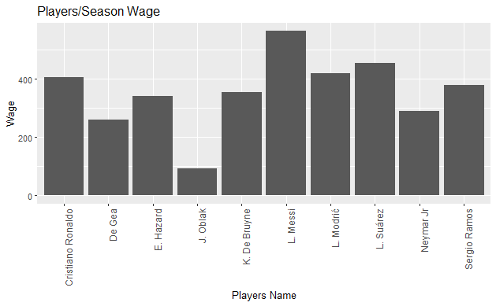

```r
graph1 <- ggplot(data = df3[1:10,],aes(x=Name,y=Wage)) + geom_bar(stat = "identity") + theme(axis.text.x = element_text(angle= 90,size = 10,hjust =1)) +  labs(title = "Players/Season Wage") +
  ylab("Wage") +
  xlab("Players Name")
graph1
```

Now showing the age of players ranges in between

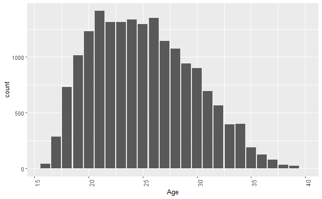

```r
graph2 <-(ggplot(df3,aes(x=Age)) + geom_bar() +   theme(axis.text.x = element_text(angle = 90,size = 10,hjust = 1)) +lims(x = c(NA,40)))
suppressWarnings(print(graph2))
```

Showing the prefered foot of players

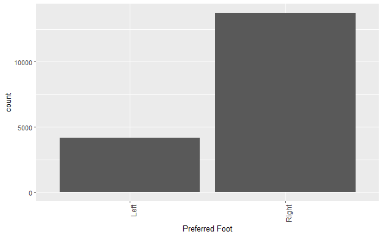

```r
graph3 <- ggplot(df3,aes(x=`Preferred Foot`)) + geom_bar() + theme(axis.text.x = element_text(angle = 90,size = 10,hjust = 1))
graph3
```

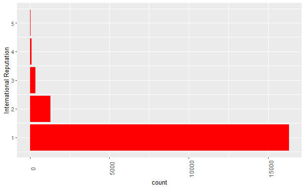

```r
graph4 <- ggplot(df3,aes(x=`International Reputation`)) + geom_bar(color="red",fill="red") + theme(axis.text.x = element_text(angle = 90,size = 10))  + coord_flip()

graph4
```

Showing the skewness of the data in overall column

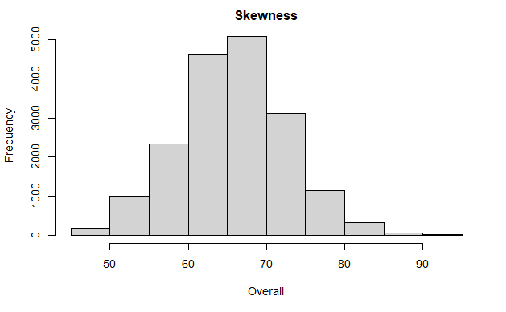

```r
hist(df3$Overall,main="Skewness", xlab="Overall")
```

```r
skewness(df3$Overall)
```

```
[1] 0.06752384
```

Check the variable

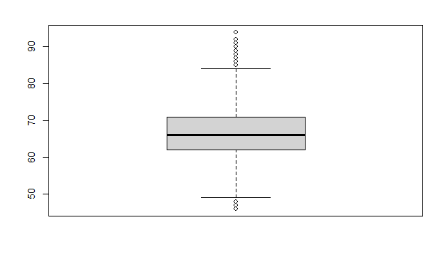

```r
boxplot(df3$Overall)
```

showing the density plots of some data

```r
g_d = ggplot(data=df3,aes(x=Overall)) + geom_density(fill="blue",color="red")
g_d1 = ggplot(data=df3,aes(x=Crossing)) + geom_density(fill="blue",color="red")
g_d2 = ggplot(data=df3,aes(x=Finishing)) + geom_density(fill="blue",color="red")
g_d3 = ggplot(data=df3,aes(x=Wage)) + geom_density(fill="blue",color="red")
```

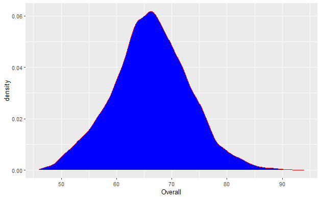

```r
g_d
```

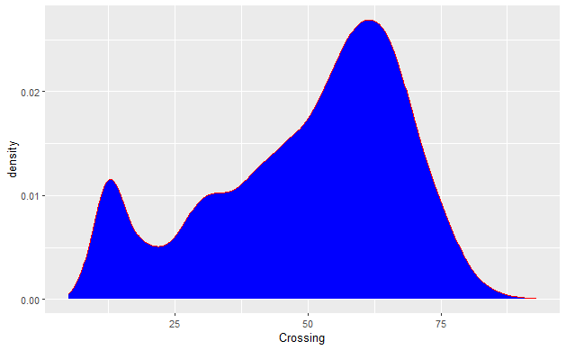

```r
g_d1
```

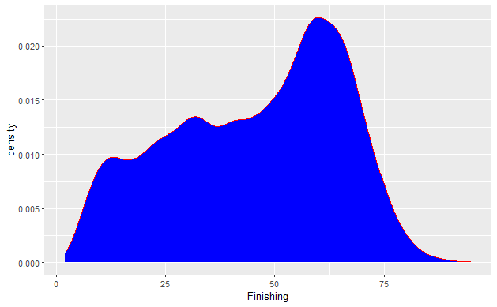

```r
g_d2
```

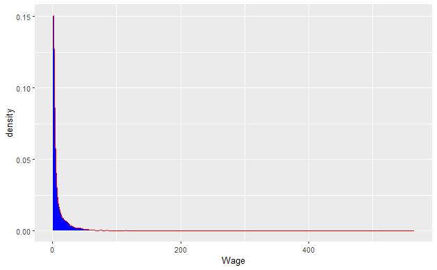

```r
g_d3
```

```r
cor_df <- cor(df3[,unlist(lapply(df3, is.numeric))])
head(round(cor_df,2))
```

```
             ID   Age Overall Potential Value  Wage International Reputation Weak Foot Skill Moves Crossing Finishing
ID         1.00 -0.74   -0.42      0.05    NA -0.20                    -0.36     -0.08       -0.06    -0.13     -0.08
Age       -0.74  1.00    0.45     -0.25    NA  0.14                     0.25      0.06        0.03     0.13      0.07
Overall   -0.42  0.45    1.00      0.66    NA  0.58                     0.50      0.21        0.42     0.40      0.33
Potential  0.05 -0.25    0.66      1.00    NA  0.49                     0.37      0.16        0.35     0.25      0.24
Value        NA    NA      NA        NA     1    NA                       NA        NA          NA       NA        NA
Wage      -0.20  0.14    0.58      0.49    NA  1.00                     0.67      0.14        0.26     0.23      0.22
          HeadingAccuracy ShortPassing Volleys Dribbling Curve FKAccuracy LongPassing BallControl Acceleration SprintSpeed
ID                  -0.11        -0.14   -0.16     -0.03 -0.17      -0.20       -0.19       -0.10         0.13        0.13
Age                  0.15         0.13    0.14      0.01  0.14       0.20        0.18        0.09        -0.16       -0.15
Overall              0.34         0.50    0.39      0.37  0.42       0.40        0.48        0.46         0.20        0.21
Potential            0.20         0.37    0.25      0.32  0.28       0.23        0.32        0.36         0.24        0.24
Value                  NA           NA      NA        NA    NA         NA          NA          NA           NA          NA
Wage                 0.19         0.30    0.26      0.24  0.26       0.24        0.28        0.28         0.13        0.13
          Agility Reactions Balance ShotPower Jumping Stamina Strength LongShots Aggression Interceptions Positioning Vision
ID          -0.02     -0.41    0.05     -0.17   -0.17   -0.06    -0.26     -0.16      -0.23         -0.16       -0.09  -0.22
Age         -0.02      0.45   -0.09      0.16    0.18    0.10     0.33      0.16       0.27          0.20        0.08   0.19
Overall      0.27      0.85    0.10      0.44    0.27    0.37     0.35      0.42       0.40          0.32        0.36   0.50
Potential    0.22      0.51    0.14      0.29    0.11    0.20     0.08      0.27       0.17          0.16        0.25   0.35
Value          NA        NA      NA        NA      NA      NA       NA        NA         NA            NA          NA     NA
Wage         0.16      0.50    0.09      0.26    0.13    0.18     0.14      0.25       0.20          0.16        0.23   0.32
          Penalties Composure Marking StandingTackle SlidingTackle GKDiving GKHandling GKKicking GKPositioning GKReflexes
ID            -0.14     -0.39   -0.11          -0.09         -0.07    -0.11      -0.11     -0.11         -0.12      -0.11
Age            0.14      0.39    0.14           0.12          0.10     0.10       0.11      0.10          0.12       0.10
Overall        0.34      0.73    0.29           0.25          0.22    -0.03      -0.03     -0.03         -0.02      -0.02
Potential      0.22      0.44    0.16           0.14          0.13    -0.05      -0.05     -0.06         -0.05      -0.05
Value            NA        NA      NA             NA            NA       NA         NA        NA            NA         NA
Wage           0.22      0.42    0.15           0.13          0.11    -0.03      -0.02     -0.03         -0.03      -0.03
```

Finding any significance difference between left or right preffered foot

```r
xt1 <- df3 %>% filter(`Preferred Foot` == "Left") %>% select(`Skill Moves`) %>% pull()
xt2 <- df3 %>% filter(`Preferred Foot` == "Right") %>% select(`Skill Moves`) %>% pull()
yt1 <- df3 %>% filter(`Preferred Foot` == "Left") %>% select(`Finishing`) %>% pull()
yt2 <- df3 %>% filter(`Preferred Foot` == "Right") %>% select(`Finishing`) %>% pull()
xht <- wilcox.test(xt1, xt2, alternative = "two.sided")
yht <- wilcox.test(yt1, yt2, alternative = "two.sided")
xht
```

```
    Wilcoxon rank sum test with continuity correction

data:  xt1 and xt2
W = 32374896, p-value < 2.2e-16
alternative hypothesis: true location shift is not equal to 0
```

```r
yht
```

```
    Wilcoxon rank sum test with continuity correction

data:  yt1 and yt2
W = 29733213, p-value = 0.0001528
alternative hypothesis: true location shift is not equal to 0
```

Removing some more columns

```r
colnames(df3)
```

```
 [1] "ID"                       "Name"                     "Age"                      "Nationality"
 [5] "Overall"                  "Potential"                "Club"                     "Value"
 [9] "Wage"                     "Preferred Foot"           "International Reputation" "Weak Foot"
[13] "Skill Moves"              "Height"                   "Weight"                   "Crossing"
[17] "Finishing"                "HeadingAccuracy"          "ShortPassing"             "Volleys"
[21] "Dribbling"                "Curve"                    "FKAccuracy"               "LongPassing"
[25] "BallControl"              "Acceleration"             "SprintSpeed"              "Agility"
[29] "Reactions"                "Balance"                  "ShotPower"                "Jumping"
[33] "Stamina"                  "Strength"                 "LongShots"                "Aggression"
[37] "Interceptions"            "Positioning"              "Vision"                   "Penalties"
[41] "Composure"                "Marking"                  "StandingTackle"           "SlidingTackle"
[45] "GKDiving"                 "GKHandling"               "GKKicking"                "GKPositioning"
[49] "GKReflexes"
```

```r
df4 <- df3[,-c(1,2,3,4,7,8,9,10,14,15)]
dim(df4)
```

```
[1] 17918    39
```

```r
colnames(df4)
```

```
 [1] "Overall"                  "Potential"                "International Reputation" "Weak Foot"
 [5] "Skill Moves"              "Crossing"                 "Finishing"                "HeadingAccuracy"
 [9] "ShortPassing"             "Volleys"                  "Dribbling"                "Curve"
[13] "FKAccuracy"               "LongPassing"              "BallControl"              "Acceleration"
[17] "SprintSpeed"              "Agility"                  "Reactions"                "Balance"
[21] "ShotPower"                "Jumping"                  "Stamina"                  "Strength"
[25] "LongShots"                "Aggression"               "Interceptions"            "Positioning"
[29] "Vision"                   "Penalties"                "Composure"                "Marking"
[33] "StandingTackle"           "SlidingTackle"            "GKDiving"                 "GKHandling"
[37] "GKKicking"                "GKPositioning"            "GKReflexes"
```

Splitiing the data

```r
sum(is.na(df4))
```

```
[1] 0
```

```r
train_r <- df4[1:12000,]
test_r <- df4[12001:17918,]
dim(train_r)
```

```
[1] 12000    39
```

```r
dim(test_r)
```

```
[1] 5918   39
```

Applying multilinear regression

```r
train <- lm(train_r$Overall ~ .,data = train_r)
summary(train)
```

```
Call:
lm(formula = train_r$Overall ~ ., data = train_r)

Residuals:
    Min      1Q  Median      3Q     Max
-7.5074 -1.1996  0.0219  1.2192  6.7066

Coefficients:
                            Estimate Std. Error t value Pr(>|t|)
(Intercept)                11.576394   0.335738  34.480  < 2e-16 ***
Potential                   0.276170   0.004117  67.079  < 2e-16 ***
`International Reputation`  1.569953   0.044177  35.538  < 2e-16 ***
`Weak Foot`                 0.006912   0.026770   0.258 0.796250
`Skill Moves`               0.505706   0.044593  11.340  < 2e-16 ***
Crossing                    0.016724   0.002235   7.483 7.75e-14 ***
Finishing                   0.011998   0.002741   4.377 1.21e-05 ***
HeadingAccuracy             0.048982   0.002334  20.988  < 2e-16 ***
ShortPassing                0.048991   0.004343  11.281  < 2e-16 ***
Volleys                    -0.004960   0.002320  -2.137 0.032579 *
Dribbling                  -0.015746   0.003723  -4.229 2.36e-05 ***
Curve                       0.003264   0.002293   1.424 0.154569
FKAccuracy                  0.009313   0.001992   4.676 2.95e-06 ***
LongPassing                 0.003033   0.002923   1.038 0.299368
BallControl                 0.058806   0.004764  12.344  < 2e-16 ***
Acceleration                0.005693   0.003409   1.670 0.094912 .
SprintSpeed                 0.012874   0.003122   4.124 3.76e-05 ***
Agility                     0.005116   0.002604   1.965 0.049480 *
Reactions                   0.214307   0.003664  58.486  < 2e-16 ***
Balance                    -0.012551   0.002293  -5.473 4.51e-08 ***
ShotPower                   0.014349   0.002527   5.678 1.39e-08 ***
Jumping                     0.004824   0.001712   2.817 0.004851 **
Stamina                     0.011549   0.002066   5.589 2.33e-08 ***
Strength                    0.022220   0.002270   9.790  < 2e-16 ***
LongShots                  -0.007063   0.002642  -2.673 0.007527 **
Aggression                  0.011652   0.001842   6.324 2.63e-10 ***
Interceptions               0.004023   0.002656   1.514 0.129937
Positioning                -0.027448   0.002646 -10.375  < 2e-16 ***
Vision                     -0.012741   0.002430  -5.243 1.60e-07 ***
Penalties                   0.007330   0.002238   3.275 0.001059 **
Composure                   0.067662   0.002778  24.357  < 2e-16 ***
Marking                     0.016436   0.002160   7.608 2.98e-14 ***
StandingTackle             -0.004921   0.003917  -1.256 0.208993
SlidingTackle              -0.007135   0.003638  -1.961 0.049853 *
GKDiving                    0.034724   0.005094   6.817 9.76e-12 ***
GKHandling                  0.042369   0.005080   8.341  < 2e-16 ***
GKKicking                   0.018186   0.004702   3.868 0.000111 ***
GKPositioning               0.045115   0.005037   8.957  < 2e-16 ***
GKReflexes                  0.037229   0.005011   7.430 1.16e-13 ***
---
Signif. codes:  0 ‘***’ 0.001 ‘**’ 0.01 ‘*’ 0.05 ‘.’ 0.1 ‘ ’ 1

Residual standard error: 1.831 on 11961 degrees of freedom
Multiple R-squared:  0.8559,    Adjusted R-squared:  0.8554
F-statistic:  1869 on 38 and 11961 DF,  p-value: < 2.2e-16
```

plotting the model

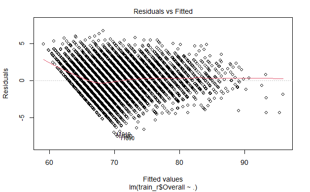

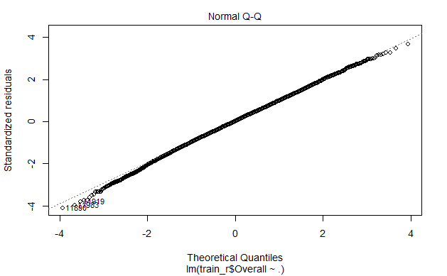

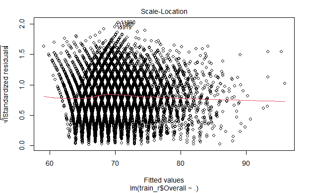

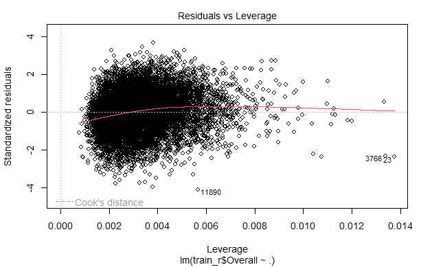

```r
plot(train)
```

Now predict the value with model

```r
yp <- predict(train,test_r)
View(yp)
predict_value <- yp
p_v_d <- data.frame(predict_value=yp,actual=test_r$Overall)
dim(p_v_d)
```

```
[1] 5918    2
```